# Keras- Show casing MLP vs CNN

[figure not shown]

##### Keras model module

```
# Multilayer Perceptron is a sequence of multiple neural network Layers
# Import the Sequential model type from Keras. This is an interface to build a linear stack of neural network layers
```

```python
from keras.models import Sequential
```

```python
cont=dir(Sequential)
print(cont)
```

[output not shown]

##### Keras core layers

```
Import the "core" layers from Keras. These are the layers that are used in almost any neural network:
```

```python
from keras.layers import core
```

```python
cont=dir(core)
print(cont)
```

```
['Activation', 'ActivityRegularization', 'Dense', 'Dropout', 'Flatten', 'InputSpec', 'K', 'Lambda', 'Layer', 'Masking', 'Permute', 'RepeatVector', 'Reshape', 'SpatialDropout1D', 'SpatialDropout2D', 'SpatialDropout3D', '__builtins__', '__cached__', '__doc__', '__file__', '__loader__', '__name__', '__…
```

##### Keras CNN layers

```
 Import the CNN layers from Keras. These are the convolutional layers that will help us efficiently train on image data:
```

```python
from keras.layers import convolutional, pooling
```

#### Load image data from MNIST.

```
MNIST database of handwritten digits

Dataset of 60,000 28x28 grayscale images of the 10 digits, along with a test set of 10,000 images.
```

```python
from keras.datasets import mnist

# Load pre-shuffled MNIST data into train and test sets
(X_train, y_train), (X_test, y_test) = mnist.load_data()
```

```python
X_train[0]
```

```
array([[  0,   0,   0,   0,   0,   0,   0,   0,   0,   0,   0,   0,   0,
          0,   0,   0,   0,   0,   0,   0,   0,   0,   0,   0,   0,   0,
          0,   0],
       [  0,   0,   0,   0,   0,   0,   0,   0,   0,   0,   0,   0,   0,
          0,   0,   0,   0,   0,   0,   0,   0,   0,   0,   0,   0,   0,
          0,   0],
       [  0,   0,   0,   0,   0,   0,   0,   0,   0,   0,   0,   0,   0,
          0,   0,   0,   0,   0,   0,   0,   0,   0,   0,   0,   0,   0,
          0,   0],
       [  0,   0,   0,   0,   0,   0,   0,   0,   0,   0,   0,   0,   0,
          0,   0,   0,   0,   0,   0,   0,   0,   0,   0,   0,   0,   0,
          0,   0],
       [  0,   0,   0,   0,   0,   0,   0,   0,   0,   0,   0,   0,   0,
          0,   0,   0,   0,   0,   0,   0,   0,   0,   0,   0,   0,   0,
          0,   0],
       [  0,   0,   0,   0,   0,   0,   0,   0,   0,   0,   0,   0,   3,
         18,  18,  18, 126, 136, 175,  26, 166, 255, 247, 127,   0,   0,
          0,   0],
       [  0,   0,   0,   0,   0,   0,   0,   0,  30,  36,  94, 154, 170,
        253, 253, 253, 253, 253, 225, 172, 253, 242, 195,  64,   0,   0,
          0,   0],
       [  0,   0,   0,   0,   0,   0,   0,  49, 238, 253, 253, 253, 253,
        253, 253, 253, 253, 251,  93,  82,  82,  56,  39,   0,   0,   0,
          0,   0],
       [  0,   0,   0,   0,   0,   0,   0,  18, 219, 253, 253, 253, 253,
        253, 198, 182, 247, 241,   0,   0,   0,   0,   0,   0,   0,   0,
          0,   0],
       [  0,   0,   0,   0,   0,   0,   0,   0,  80, 156, 107, 253, 253,
        205,  11,   0,  43, 154,   0,   0,   0,   0,   0,   0,   0,   0,
          0,   0],
       [  0,   0,   0,   0,   0,   0,   0,   0,   0,  14,   1, 154, 253,
         90,   0,   0,   0,   0,   0,   0,   0,   0,   0,   0,   0,   0,
          0,   0],
       [  0,   0,   0,   0,   0,   0,   0,   0,   0,   0,   0, 139, 253,
        190,   2,   0,   0,   0,   0,   0,   0,   0,   0,   0,   0,   0,
          0,   0],
       [  0,   0,   0,   0,   0,   0,   0,   0,   0,   0,   0,  11, 190,
        253,  70,   0,   0,   0,   0,   0,   0,   0,   0,   0,   0,   0,
          0,   0],
       [  0,   0,   0,   0,   0,   0,   0,   0,   0,   0,   0,   0,  35,
```

[output cut: 29 more lines]

```
       [  0,   0,   0,   0,  55, 172, 226, 253, 253, 253, 253, 244, 133,
         11,   0,   0,   0,   0,   0,   0,   0,   0,   0,   0,   0,   0,
          0,   0],
       [  0,   0,   0,   0, 136, 253, 253, 253, 212, 135, 132,  16,   0,
          0,   0,   0,   0,   0,   0,   0,   0,   0,   0,   0,   0,   0,
          0,   0],
       [  0,   0,   0,   0,   0,   0,   0,   0,   0,   0,   0,   0,   0,
          0,   0,   0,   0,   0,   0,   0,   0,   0,   0,   0,   0,   0,
          0,   0],
       [  0,   0,   0,   0,   0,   0,   0,   0,   0,   0,   0,   0,   0,
          0,   0,   0,   0,   0,   0,   0,   0,   0,   0,   0,   0,   0,
          0,   0],
       [  0,   0,   0,   0,   0,   0,   0,   0,   0,   0,   0,   0,   0,
          0,   0,   0,   0,   0,   0,   0,   0,   0,   0,   0,   0,   0,
          0,   0]], dtype=uint8)
```

```python
y_train[0]
```

```
5
```

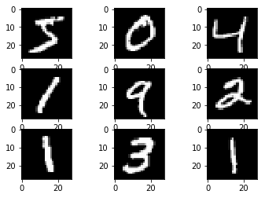

```python
# plot first few images of train
from matplotlib import pyplot
for i in range(9):
    # define subplot
    pyplot.subplot(330 + 1 + i)
    # plot raw pixel data
    pyplot.imshow(X_train[i], cmap=pyplot.get_cmap('gray'))
# show the figure
pyplot.show()
```

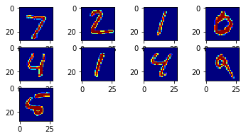

```python
# plot first few images of train
from matplotlib import pyplot
for i in range(9):
    # define subplot
    pyplot.subplot(440+1+i)
    # plot raw pixel data
    pyplot.imshow(X_test[i], cmap=pyplot.get_cmap('jet'))
# show the figure
pyplot.show()
```

Returns:

```
2 tuples:
        x_train, x_test: uint8 array of grayscale image data with shape (num_samples, 28, 28).
        y_train, y_test: uint8 array of digit labels (integers in range 0-9) with shape (num_samples,).
```

Arguments:

```
path: if you do not have the index file locally (at '~/.keras/datasets/' + path), it will be downloaded to this location.
```

Look at the shape of the dataset:

```python
print (X_train.shape, y_train.shape, X_test.shape, y_test.shape)
```

```
(60000, 28, 28) (60000,) (10000, 28, 28) (10000,)
```

## MLP for MNIST Digit Recognition

### Prepare MNIST Data for MLP

Convert our data type to float32 and normalize our data values to the range [0, 1]

Note: Max value X_train/X_test can take is 255, so it is divided by 255

```python
X_train = X_train.astype('float32')
X_test = X_test.astype('float32')
X_train /= 255
X_test /= 255
```

```python
X_train[0]
```

```
array([[0.        , 0.        , 0.        , 0.        , 0.        ,
        0.        , 0.        , 0.        , 0.        , 0.        ,
        0.        , 0.        , 0.        , 0.        , 0.        ,
        0.        , 0.        , 0.        , 0.        , 0.        ,
        0.        , 0.        , 0.        , 0.        , 0.        ,
        0.        , 0.        , 0.        ],
       [0.        , 0.        , 0.        , 0.        , 0.        ,
        0.        , 0.        , 0.        , 0.        , 0.        ,
        0.        , 0.        , 0.        , 0.        , 0.        ,
        0.        , 0.        , 0.        , 0.        , 0.        ,
        0.        , 0.        , 0.        , 0.        , 0.        ,
        0.        , 0.        , 0.        ],
       [0.        , 0.        , 0.        , 0.        , 0.        ,
        0.        , 0.        , 0.        , 0.        , 0.        ,
        0.        , 0.        , 0.        , 0.        , 0.        ,
        0.        , 0.        , 0.        , 0.        , 0.        ,
        0.        , 0.        , 0.        , 0.        , 0.        ,
        0.        , 0.        , 0.        ],
       [0.        , 0.        , 0.        , 0.        , 0.        ,
        0.        , 0.        , 0.        , 0.        , 0.        ,
        0.        , 0.        , 0.        , 0.        , 0.        ,
        0.        , 0.        , 0.        , 0.        , 0.        ,
        0.        , 0.        , 0.        , 0.        , 0.        ,
        0.        , 0.        , 0.        ],
       [0.        , 0.        , 0.        , 0.        , 0.        ,
        0.        , 0.        , 0.        , 0.        , 0.        ,
        0.        , 0.        , 0.        , 0.        , 0.        ,
        0.        , 0.        , 0.        , 0.        , 0.        ,
        0.        , 0.        , 0.        , 0.        , 0.        ,
        0.        , 0.        , 0.        ],
       [0.        , 0.        , 0.        , 0.        , 0.        ,
        0.        , 0.        , 0.        , 0.        , 0.        ,
        0.        , 0.        , 0.01176471, 0.07058824, 0.07058824,
        0.07058824, 0.49411765, 0.53333336, 0.6862745 , 0.10196079,
        0.6509804 , 1.        , 0.96862745, 0.49803922, 0.        ,
        0.        , 0.        , 0.        ],
       [0.        , 0.        , 0.        , 0.        , 0.        ,
        0.        , 0.        , 0.        , 0.11764706, 0.14117648,
        0.36862746, 0.6039216 , 0.6666667 , 0.99215686, 0.99215686,
        0.99215686, 0.99215686, 0.99215686, 0.88235295, 0.6745098 ,
```

[output cut: 113 more lines]

```
        0.        , 0.        , 0.        , 0.        , 0.        ,
        0.        , 0.        , 0.        , 0.        , 0.        ,
        0.        , 0.        , 0.        ],
       [0.        , 0.        , 0.        , 0.        , 0.        ,
        0.        , 0.        , 0.        , 0.        , 0.        ,
        0.        , 0.        , 0.        , 0.        , 0.        ,
        0.        , 0.        , 0.        , 0.        , 0.        ,
        0.        , 0.        , 0.        , 0.        , 0.        ,
        0.        , 0.        , 0.        ],
       [0.        , 0.        , 0.        , 0.        , 0.        ,
        0.        , 0.        , 0.        , 0.        , 0.        ,
        0.        , 0.        , 0.        , 0.        , 0.        ,
        0.        , 0.        , 0.        , 0.        , 0.        ,
        0.        , 0.        , 0.        , 0.        , 0.        ,
        0.        , 0.        , 0.        ]], dtype=float32)
```

#### Preprocess class labels for Keras

Look at the shape of our class label data

```python
print (y_train.shape)
```

```
(60000,)
```

We should have 10 different classes, one for each digit, but it looks like we only have a 1-dimensional array.

```python
print (y_train[:10])
```

```
[5 0 4 1 9 2 1 3 1 4]
```

##### Convert 1-dimensional class arrays to 10-dimensional class matrices

```python
from keras.utils import to_categorical
```

```python
Y_train = to_categorical(y_train, 10)
Y_test = to_categorical(y_test, 10)
```

```python
y_train[0]
```

```
5
```

Take another look:

```python
print (Y_train.shape)
```

```
(60000, 10)
```

```python
print (Y_train)
```

```
[[0. 0. 0. ... 0. 0. 0.]
 [1. 0. 0. ... 0. 0. 0.]
 [0. 0. 0. ... 0. 0. 0.]
 ...
 [0. 0. 0. ... 0. 0. 0.]
 [0. 0. 0. ... 0. 0. 0.]
 [0. 0. 0. ... 0. 1. 0.]]
```

```python
print(X_train.shape)
```

```
(60000, 28, 28)
```

```python
# Same number of samples, but flatten the 28, 28 to 28*28 (784)

X_train_mlp = X_train.reshape(X_train.shape[0], X_train.shape[1] * X_train.shape[2])

X_test_mlp = X_test.reshape(X_test.shape[0], X_test.shape[1] * X_test.shape[2])
```

```python
print (X_train_mlp.shape, y_train.shape, X_test_mlp.shape, y_test.shape)
```

```
(60000, 784) (60000,) (10000, 784) (10000,)
```

```python
from keras.models import Sequential
from keras.layers.core import Activation, Dense, Dropout
from keras.layers.normalization import BatchNormalization
```

```python
model = Sequential()
model.add(Dense(512, input_shape=(784,)))
model.add(Activation("relu"))
model.add(Dropout(0.2))
model.add(BatchNormalization())
model.add(Dense(256))
model.add(Activation("relu"))
model.add(Dropout(0.2))
model.add(BatchNormalization())
model.add(Dense(10))
model.add(Activation("softmax"))
```

```python
model.summary()
```

```
Model: "sequential_1"
_________________________________________________________________
Layer (type)                 Output Shape              Param #
=================================================================
dense_1 (Dense)              (None, 512)               401920
_________________________________________________________________
activation_1 (Activation)    (None, 512)               0
_________________________________________________________________
dropout_1 (Dropout)          (None, 512)               0
_________________________________________________________________
batch_normalization_1 (Batch (None, 512)               2048
_________________________________________________________________
dense_2 (Dense)              (None, 256)               131328
_________________________________________________________________
activation_2 (Activation)    (None, 256)               0
_________________________________________________________________
dropout_2 (Dropout)          (None, 256)               0
_________________________________________________________________
batch_normalization_2 (Batch (None, 256)               1024
_________________________________________________________________
dense_3 (Dense)              (None, 10)                2570
_________________________________________________________________
activation_3 (Activation)    (None, 10)                0
=================================================================
Total params: 538,890
Trainable params: 537,354
Non-trainable params: 1,536
_________________________________________________________________
```

```python
model.compile(loss="categorical_crossentropy", optimizer="adam", metrics=["accuracy"])
```

```python
history = model.fit(X_train_mlp, Y_train, validation_split = 0.2,
                    batch_size = 48000, epochs = 5)
```

```
Train on 48000 samples, validate on 12000 samples
```

```python
model.save('final_model.h5')
```

```python
import matplotlib.pyplot as plt
```

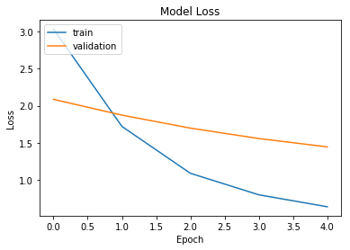

```python
plt.plot(history.history["loss"])
plt.plot(history.history["val_loss"])
plt.title("Model Loss")
plt.xlabel("Epoch")
plt.ylabel("Loss")
plt.legend(["train", "validation"], loc="upper left")
plt.show()
```

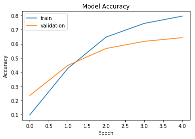

```python
plt.plot(history.history["accuracy"])
plt.plot(history.history["val_accuracy"])
plt.title("Model Accuracy")
plt.xlabel("Epoch")
plt.ylabel("Accuracy")
plt.legend(["train", "validation"], loc="upper left")
plt.show()
```

```python
scores = model.evaluate(X_test_mlp, Y_test, verbose=0)

print("[INFO] test score - {}".format(scores[0]))

print("[INFO] test accuracy - {}".format(scores[1]))
```

```
[INFO] test score - 1.4550163118362427
[INFO] test accuracy - 0.6323000192642212
```

```python
#predict
digit = model.predict_classes(X_test_mlp)
```

```python
print(digit[2])
```

```
8
```

```python
print(y_test[2])
```

```
1
```

```python
print(digit[0:10])
```

```
[7 2 8 0 4 8 8 9 8 9]
```

# predicting new data

```python
import os
os.getcwd()
```

```
'C:\\Users\\dhanasree\\Desktop\\JNTUA_NN\\IT_CNN\\CNN-MNIST'
```

```python
os.chdir('C:\\Users\\dhanasree\\Desktop\\JNTUA_NN\\CNN-MNIST\\sample_img')
```

```python
#predict a new image
# load and prepare the image
def load_image(filename):
    # load the image
    img = load_img(filename, grayscale=True, target_size=(28, 28))
    # convert to array
    img = img_to_array(img)
    # reshape into a single sample with 1 channel
    img = img.reshape(1,784)
    # prepare pixel data
    img = img.astype('float32')
    img = img / 255.0
    return img
```

```python
from keras.preprocessing.image import load_img
from keras.preprocessing.image import img_to_array
from keras.models import load_model
```

```python
# load an image and predict the class
def run_example():
    # load the image
    img = load_image('sample_image.png')
    # load model
    model = load_model('final_model.h5')
    # predict the class
    digit = model.predict_classes(img)
    print(digit[0])
#entry point, run the example
run_example()
```

```
7
```

# What are CNNs?

- How are images represented again?

[figure not shown]

- What is a CNN?

[figure not shown]

- The four main operations in a CNN:
  - Convolution
  - Non Linearity (ReLU)
  - Pooling or Sub Sampling
  - Classification (Fully Connected Layer)
- Some important convolving operations used in ML based image classifiers, before deep learning

[figure not shown]

## Understanding Convolutions

[figure not shown]

### Output Feature Map Dimensions after Convolving

[figure not shown]

```
    W - Width of the input feature map

    K - Width of the Kernel / Filter

    P - Padding Layer dimension

    S - Stride
```

### Zero Padding in Keras

In Keras we have two types of Padding:

```
  (i) Valid Padding : Any layer that does not fully intersect with the filter is ignored (NO PADDING!)

  (ii) Same Padding : Adds Zero Padding such that the output feature map has similar dimensions to the input                      feature map
```

[figure not shown]

## CNN for MNIST Digit Recognition

#### Preprocess input data for Keras

```python
print (X_train.shape[0])
```

```
60000
```

Reshape input data

```
When using the tensorflow backend, you must explicitly declare a dimension for the depth of the input image.
E.g. a full-color image with all 3 RGB channels will have a depth of 3.

Our MNIST images only have a depth of 1, but we must explicitly declare that.

In other words, we want to transform our dataset from having shape (n, width, height) to (n, width, height, channel).
```

```python
X_train_cnn = X_train.reshape(X_train.shape[0], X_train.shape[1], X_train.shape[2], 1)
X_test_cnn = X_test.reshape(X_test.shape[0], 28, 28, 1)
```

print X_train's dimensions

```python
print (X_train.shape)
print (X_train_cnn.shape)
```

```
(60000, 28, 28)
(60000, 28, 28, 1)
```

#### Define model architecture.

Declaring a sequential model

```python
cnn_model = Sequential()
```

Declare the input layer

CNN input layer

```python
from keras.layers.convolutional import Conv2D
```

```python
cnn_model.add(Conv2D(filters = 64, kernel_size = (3, 3), strides = (1,1), activation='relu', input_shape=(28,28,1)))
```

###### 2D convolution layer (e.g. spatial convolution over images).

This layer creates a convolution kernel that is convolved with the layer input to produce a tensor of outputs. If use_bias is True, a bias vector is created and added to the outputs. Finally, if activation is not None, it is applied to the outputs as well.

When using this layer as the first layer in a model, provide the keyword argument input_shape (tuple of integers, does not include the sample axis), e.g. input_shape=(28, 28, 1) for 28x28 gray pictures in data_format="channels_last".

First parameters correspond to the number of convolution filters

Next 2 parameters correspond to kernal size

###### Add more layers to our model

[figure not shown]

```python
from keras.layers.pooling import MaxPooling2D
```

```python
cnn_model.add(Conv2D(filters = 32, kernel_size = (3, 3), strides = (1,1), activation='relu'))
cnn_model.add(MaxPooling2D(pool_size=(2, 2)))
cnn_model.add(Dropout(0.25))
```

```python
cnn_model.add(Conv2D(filters = 64, kernel_size = (3, 3), strides = (1,1), activation='relu'))
cnn_model.add(MaxPooling2D(pool_size=(2, 2)))
cnn_model.add(Dropout(0.25))
```

```python
cnn_model.add(Conv2D(filters = 32, kernel_size = (3, 3), strides = (1,1), activation='relu'))
cnn_model.add(MaxPooling2D(pool_size=(2, 2)))
cnn_model.add(Dropout(0.25))
```

Dropout

```
This is a method for regularizing our model in order to prevent overfitting.
```

MaxPooling2D

```
Is a way to reduce the number of parameters in our model by sliding a 2x2 pooling filter across the previous layer and taking the max of the 4 values in the 2x2 filter.
```

```python
from keras.layers.core import Flatten
```

```python
cnn_model.add(Flatten())
cnn_model.add(BatchNormalization())
cnn_model.add(Dense(128, activation='relu'))
cnn_model.add(Dropout(0.5))
cnn_model.add(BatchNormalization())
cnn_model.add(Dense(10, activation='softmax'))
```

For Dense layers, the first parameter is the output size of the layer. Keras automatically handles the connections between layers.

Note that the final layer has an output size of 10, corresponding to the 10 classes of digits.

Also note that the weights from the Convolution layers must be flattened (made 1-dimensional) before passing them to the fully connected Dense layer.

#### Compile model

Compile the model by providing the loss function and the optimizer

```python
from keras.optimizers import Adam
```

```python
custom_adam = Adam(lr = 0.01, decay = 0.01)
```

```python
cnn_model.compile(loss = 'categorical_crossentropy', optimizer = custom_adam, metrics = ['accuracy'])
```

```python
cnn_model.summary()
```

```
Model: "sequential_2"
_________________________________________________________________
Layer (type)                 Output Shape              Param #
=================================================================
conv2d_1 (Conv2D)            (None, 26, 26, 64)        640
_________________________________________________________________
conv2d_2 (Conv2D)            (None, 24, 24, 32)        18464
_________________________________________________________________
max_pooling2d_1 (MaxPooling2 (None, 12, 12, 32)        0
_________________________________________________________________
dropout_3 (Dropout)          (None, 12, 12, 32)        0
_________________________________________________________________
conv2d_3 (Conv2D)            (None, 10, 10, 64)        18496
_________________________________________________________________
max_pooling2d_2 (MaxPooling2 (None, 5, 5, 64)          0
_________________________________________________________________
dropout_4 (Dropout)          (None, 5, 5, 64)          0
_________________________________________________________________
conv2d_4 (Conv2D)            (None, 3, 3, 32)          18464
_________________________________________________________________
max_pooling2d_3 (MaxPooling2 (None, 1, 1, 32)          0
_________________________________________________________________
dropout_5 (Dropout)          (None, 1, 1, 32)          0
_________________________________________________________________
flatten_1 (Flatten)          (None, 32)                0
_________________________________________________________________
batch_normalization_3 (Batch (None, 32)                128
_________________________________________________________________
dense_4 (Dense)              (None, 128)               4224
_________________________________________________________________
dropout_6 (Dropout)          (None, 128)               0
_________________________________________________________________
batch_normalization_4 (Batch (None, 128)               512
_________________________________________________________________
dense_5 (Dense)              (None, 10)                1290
=================================================================
Total params: 62,218
Trainable params: 61,898
Non-trainable params: 320
_________________________________________________________________
```

#### Fit model on training data.

```python
cnn_model.fit(X_train_cnn, Y_train, batch_size = 10000, epochs = 2, validation_split = 0.2)
```

```
Train on 48000 samples, validate on 12000 samples
```

```
<keras.callbacks.callbacks.History at 0x25303ee4160>
```

```python
model.save('final_model2.h5')
```

#### Evaluate the model on test data.

```python
score = cnn_model.evaluate(X_test_cnn, Y_test)

print(score)
```

```
[0.9285841264724731, 0.7290999889373779]
```

#### Make predictions on test data

```python
# calculate predictions
predictions = cnn_model.predict(X_test_cnn)
```

```python
print (predictions)
```

```
[[9.8139876e-03 1.3071876e-04 4.0574390e-02 ... 9.3984550e-01
  6.9732094e-05 5.8318830e-05]
 [3.4216997e-01 1.0815859e-03 6.1964947e-01 ... 2.2687547e-02
  8.6941145e-04 3.3393118e-04]
 [1.2608455e-01 2.8717119e-01 9.3473300e-02 ... 6.8456784e-02
  1.2072162e-01 2.6349155e-02]
 ...
 [4.7724541e-02 5.9740469e-03 2.5867376e-02 ... 6.2802900e-03
  2.4597641e-02 2.2838037e-02]
 [1.1794868e-01 1.1776300e-02 1.2276306e-01 ... 5.3884849e-02
  1.4556216e-01 6.6029437e-02]
 [9.3843929e-02 1.7910135e-03 3.8592122e-02 ... 4.3434431e-04
  3.3240654e-03 1.0406806e-03]]
```

```python
y_pred_class = cnn_model.predict_classes(X_test_cnn)
```

```python
y_pred_class[1]
```

```
2
```

```python
y_test[1]
```

```
2
```

```python
print('actual   :', y_test[0:10])
print('predicted:', y_pred_class[0:10])
```

```
actual   : [7 2 1 0 4 1 4 9 5 9]
predicted: [7 2 1 0 0 1 4 5 0 5]
```

```python
# calculate accuracy of class predictions
from sklearn import metrics
metrics.accuracy_score(y_test, y_pred_class)
```

```
0.7291
```

```python
# print the confusion matrix
metrics.confusion_matrix(y_test, y_pred_class)
```

```
array([[974,   0,   1,   0,   0,   2,   1,   2,   0,   0],
       [ 82, 954,  25,   3,   0,   0,  24,   4,  43,   0],
       [ 23,   0, 934,  27,   2,   8,   5,  31,   2,   0],
       [  6,   0,  82, 886,   0,  18,   0,  18,   0,   0],
       [ 47,   0,   1,   0, 865,  22,  39,   3,   2,   3],
       [ 95,   1,  26,  36,   4, 707,   5,  12,   6,   0],
       [ 66,   0,   5,   0,   6,   6, 875,   0,   0,   0],
       [ 22,   0,  79,  44,   0,   3,   0, 880,   0,   0],
       [ 59,   8, 231,  90,  23, 321,  38,  27, 175,   2],
       [143,   2,   4,  13,  82, 678,   2,  39,   5,  41]], dtype=int64)
```

# predict new image

```python
# load an image and predict the class
def run_example():
    # load the image
    img = load_image('sample_image.png')
    # load model
    model = load_model('final_model2.h5')
    # predict the class
    digit = model.predict_classes(img)
    print(digit[0])
#entry point, run the example
run_example()
```

```
7
```

Reference:

```
https://keras.io/
https://elitedatascience.com
http://scikit-learn.org/stable/modules/classes.html
```

# I AM STILL LEARNING.........my thirst for learning is an unfilled vessel